# Statistics for Data Analyst and Scientist - with R

Daniel Obi-Enadhuze

2023-02-22

# Recreating The Statistical Tests in [The Statistics for Data Analyst and Scientist 2023](https://www.udemy.com/course/statistics-for-data-analysts-and-scientists/) Course By Olanrewaju

### Setting up R

```r
library(tidyverse)
library(haven)
library(car)
```

```r
library(ggplot2)
library(sjlabelled)
```

## Video 9 : Chi-squared test of independence

A chi-squared test of independence was carried out to determine if there was a relationship between the curent brand of smartphones being used by people and their preferred brand using the sample data named “phone_brand” and the following parameters:

**Null Hypothesis: No relationship exist**

**Alternative Hypothesis: A relationship exist**

**Significance Level: 5%**

### To recreate this test in R

```r
##loading the dataset
phone_brand <- read_sav("datasets//Example_data//phone_brands.sav")

#converting preferred and current from value to labels
phone_brand$preferred <- as_label(phone_brand$preferred)
phone_brand$current <- as_label(phone_brand$current)


## Creating a contingency table to represent the number of cases that fall into
## each combination of categorical variables
pb_contbl <- table(phone_brand$current, phone_brand$preferred)

#viewing contingency table
pb_contbl
```

```
##
##           Samsung HTC Apple Other
##   Samsung      27  11     4     8
##   HTC           2  25     0     3
##   Apple         3   2    17     8
##   Other         8   2     4    26
```

```r
#carrying out the chi-square test
chisq.test(pb_contbl)
```

```
##
##  Pearson's Chi-squared test
##
## data:  pb_contbl
## X-squared = 131.21, df = 9, p-value < 2.2e-16
```

### Interpretation

With a p-value less than 0.05 i.e (p-value < 2.2e-16) **we reject the null hypothesis in favor of the alternative hypothesis that states that a relationship exist between the brand of smartphone people currently use and their preferred brand.**

## Video 12: One Sample T-test

One Sample T-test was carried out to see if the average size of herrings have reduced over time from 400grams using the sample data “herrings”. The test was carried with the following parameters:

**Null Hypothesis: Sample mean is equal to 400g**

**Apparent Hypothesis: Sample mean is less than 400g**

**Significance Level: 5%**

### To recreate this test in R

```r
##loading the dataset
herrings <- read_sav("datasets//EXample_data//herrings.sav")

## Converting variable to a continuous variable
herrings$body_weight<- as.numeric(herrings$body_weight)
```

### To check if the data satisfies all the assumptions needed to carry out the test

```r
# Checking for normality of variable using the Shapiro's test
shapiro.test(herrings$body_weight)
```

```
##
##  Shapiro-Wilk normality test
##
## data:  herrings$body_weight
## W = 0.95918, p-value = 0.157
```

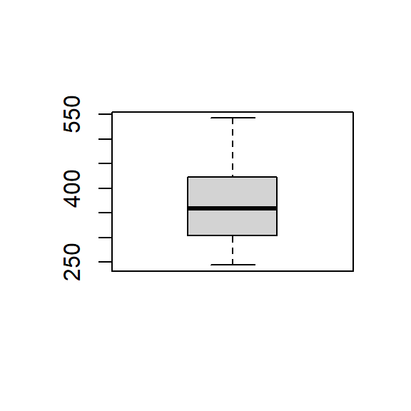

```r
# To check for outliers in the dataset
boxplot(herrings$body_weight)
```

- With a p-value greater than 0.05 (0.157) in the shapiro test for normality we fail to reject the null hypothesis, confirming normal distribution

### To carry out the t-test

```r
t.test(x = herrings$body_weight, mu = 400, alternative = "less",
       conf.level = 0.95)
```

```
##
##  One Sample t-test
##
## data:  herrings$body_weight
## t = -2.4283, df = 39, p-value = 0.009941
## alternative hypothesis: true mean is less than 400
## 95 percent confidence interval:
##      -Inf 390.6777
## sample estimates:
## mean of x
##    369.55
```

## Video 15: Independent Sample T-test

An independent sample T-test was carried out to see if women and men spend the same amount of money on clothing. 30 male and female respondents were asked their monthly expenditure on clothing, resulting into the clothing_expenses data set. The test was carried out with the following parameters:

**Null Hypothesis: Men and women spend the same amount of money on clothing**

**Alternative Hypothesis: Men and women do not spend the same amount of money on clothing**

**Significance Level: 5%**

### To recreate this test with R

```r
##loading the dataset
clothing_expenses <- read_sav("datasets//Example_data//clothing_expenses.sav")
##converting the categorical variable to label from value
clothing_expenses$gender <- as_label(clothing_expenses$gender)
```

### To check if the data satisfies all the assumptions needed to carry out the test

```r
#checking number of categorical groups
clothing_expenses %>% distinct(gender)
```

```
## # A tibble: 2 × 1
##   gender
##   <fct>
## 1 Female
## 2 Male
```

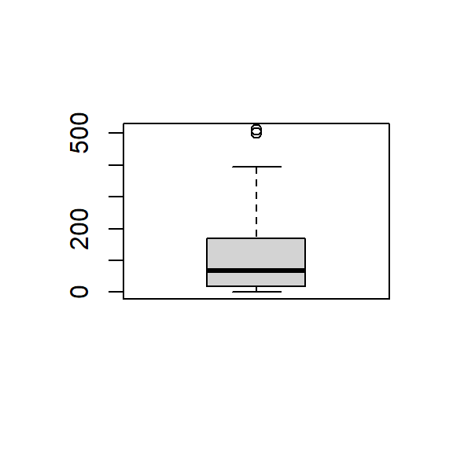

```r
#using a box plot to check for outliers
boxplot(clothing_expenses$amount_spent)
```

```r
#to check for normal distribution using shapiro test
shapiro.test(clothing_expenses$amount_spent)
```

```
##
##  Shapiro-Wilk normality test
##
## data:  clothing_expenses$amount_spent
## W = 0.81419, p-value = 3.105e-07
```

```r
#to check for equality of variances using the Levene's test
leveneTest(amount_spent ~ gender, clothing_expenses)
```

```
## Levene's Test for Homogeneity of Variance (center = median)
##       Df F value Pr(>F)
## group  1  1.3077 0.2575
##       58
```

```r
#determining the interquanrtile range
iqr <- IQR(clothing_expenses$amount_spent)
#determining the 75th percentile
q3 <- quantile(clothing_expenses$amount_spent, probs = 0.75)
#calculating upperbounds
upperbound <- q3 + (1.5*iqr)
#removing outliers from the dataset
clothing_expenses <- clothing_expenses %>% filter(amount_spent <= upperbound)
```

### To carry out the independent T-test

```r
t.test(amount_spent ~ gender, clothing_expenses, var.equal = TRUE)
```

```
##
##  Two Sample t-test
##
## data:  amount_spent by gender
## t = 1.2837, df = 55, p-value = 0.2046
## alternative hypothesis: true difference in means between group Female and group Male is not equal to 0
## 95 percent confidence interval:
##  -18.06679  82.46088
## sample estimates:
## mean in group Female   mean in group Male
##            109.71429             77.51724
```

### Interpretation

With a p-value > 0.05 (p-value = 0.2046) **we fail to reject the null hypothesis, hence confirming that there is no statistically significant difference in the average amount spent by men in buying clothes compared to women.**

## Video 18: Dependent (Paired) Sample T test

A Paired T-test was carried out to test if drinking a single glass of beer affects reaction time. The test was carried out with the following parameters

**Null Hypothesis: A single glass of beer does not affect reaction time**

**Alternative Hypothesis: A single glass of beer does affect reaction time**

**Significance Level: 5%**

### To recreate this test in R

```r
#loading the dataset
reaction_times <- read_sav("datasets//Example_data//reaction_times.sav")
```

### To check if the data satisfies all the assumptions needed to carry out the test

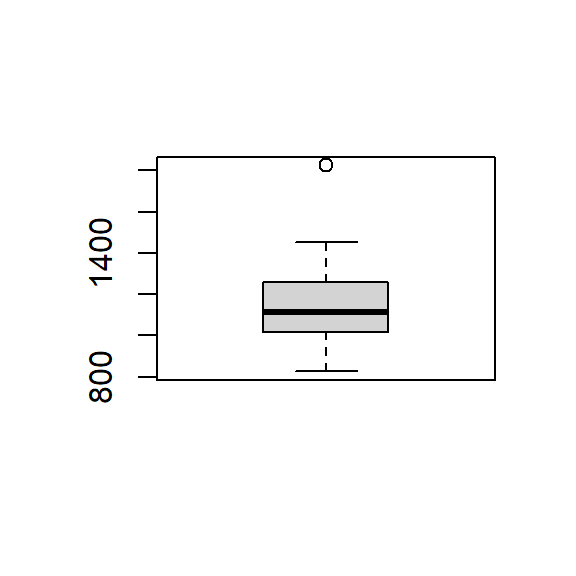

```r
#checking for outliers using boxplots
boxplot(reaction_times$reac_1)
```

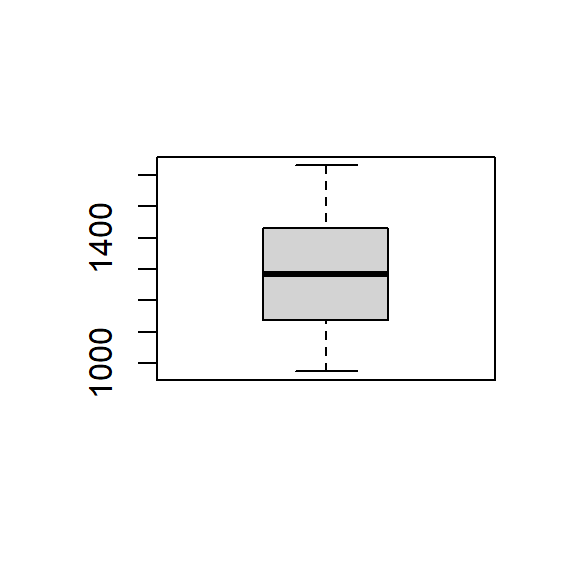

```r
boxplot(reaction_times$reac_2)
```

One outlier is identified in the “reac_1” variable, to remove it

```r
iqr <- IQR(reaction_times$reac_1)
#determining the 75th percentile
q3 <- quantile(reaction_times$reac_1, probs = 0.75)
#calculating upperbounds
upperbound <- q3 + (1.5*iqr)
#removing outliers from the dataset
reaction_times <- reaction_times %>% filter(reac_1 <= upperbound)
```

### To carry out the paired t-test

```r
t.test(reaction_times$reac_1, reaction_times$reac_2, alternative = 'two.sided',
       paired = 'TRUE')
```

```
##
##  Paired t-test
##
## data:  reaction_times$reac_1 and reaction_times$reac_2
## t = -5.2713, df = 28, p-value = 1.321e-05
## alternative hypothesis: true mean difference is not equal to 0
## 95 percent confidence interval:
##  -184.82712  -81.37977
## sample estimates:
## mean difference
##       -133.1034
```

## Video 21: Correlation Analysis

The Pearson’s correlation coefficient test was used to test whether the age and net monthly income are related in any way using the data gotten from asking 30 respondents, resulting in the age_income.sav dataset

### To recreate this test in R

```r
#importing the dataset
age_income <- read_sav("datasets//Example_data//age_income.sav")
```

### To check if the data satisfies all the assumptions needed to carry out the test

```r
#checking for normal distribution of age variable using Shapiro's test
shapiro.test(age_income$age)
```

```
##
##  Shapiro-Wilk normality test
##
## data:  age_income$age
## W = 0.94557, p-value = 0.1285
```

```r
shapiro.test(age_income$income)
```

```
##
##  Shapiro-Wilk normality test
##
## data:  age_income$income
## W = 0.97774, p-value = 0.763
```

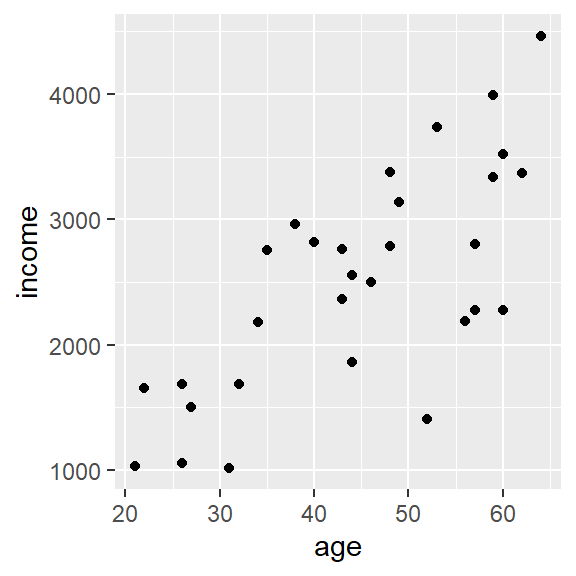

```r
#To check for the presence of a linear relationship between the variable using a scatterplot
ggplot(age_income, aes(age, income)) + geom_point()
```

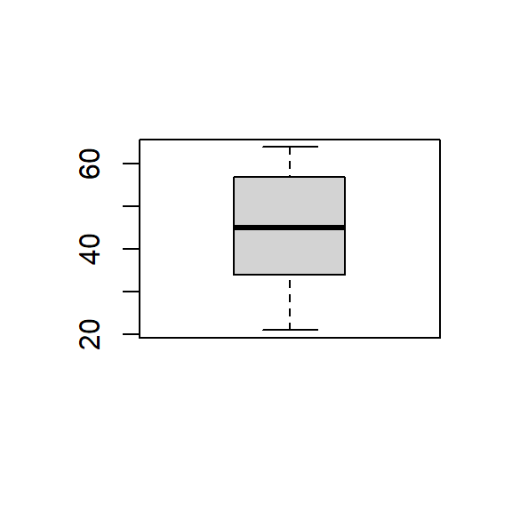

```r
#To check for the presence of outliers using boxplots
boxplot(age_income$age)
```

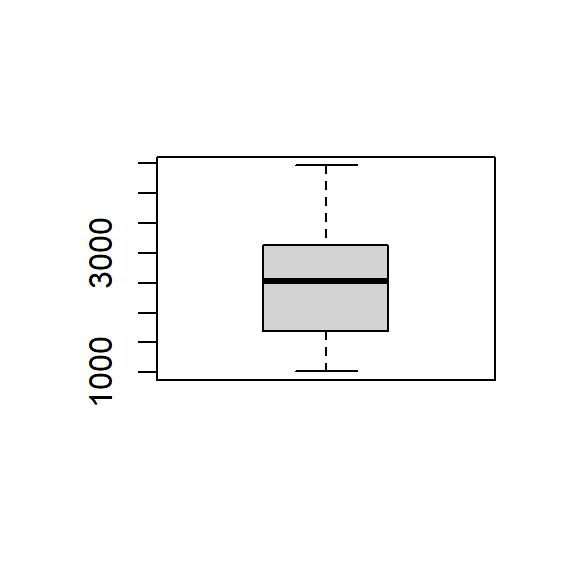

```r
boxplot(age_income$income)
```

- The shapiro test confirms the normal distribution of the dependent variables
- From the scatterplot there seems to be a positive linear relationship between the dependent variable
- The boxplot show that the dependent variable do not contain significant outliers

### To carry out the Pearson’s test

```r
cor(age_income$age, age_income$income, method = "pearson")
```

```
## [1] 0.7297846
```

### Intepretation

This value shows a strong positive correlation between the age and income of the respondents which implies that **the income increases as the age increase**.

## Video 24: Simple Linear Regression Analysis Overview

A linear regression model was created to attempt to determine exam scores in the mid-semester exam from the hours spent studying using the study_time.sav dataset which contains records of hour spent studying and exam scores of 20 students sampled. The test was carried out with the following parameters:

**Null Hypothesis: The more time you study doesn’t mean the higher exam score**

**Alternative Hypothesis: The more time you study, the higher your exam score**

**Confidence level: 95%**

### To recreate this test in R

```r
#import dataset
study_time <-  read_sav("datasets//Example_data//study_time.sav")
attach(study_time)

#To create the linear model
model <- lm(Exam_scores ~ Hours)
```

### To check if the data satisfies all the assumptions needed to carry out the test

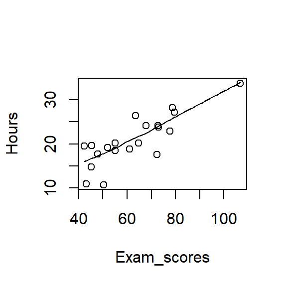

```r
#checking for linear relatioship between variables
scatter.smooth(Exam_scores, Hours)
```

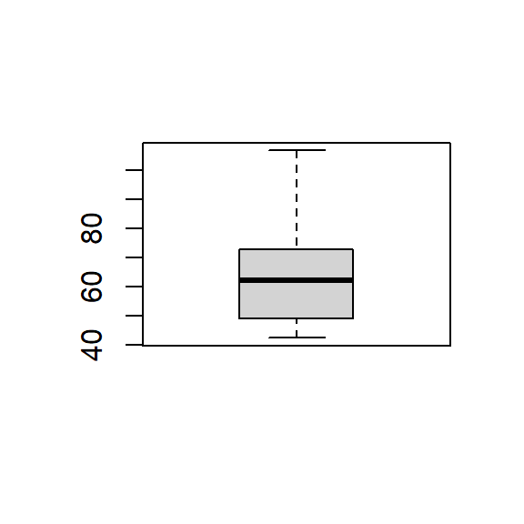

```r
#checking for outliers using a boxplot
boxplot(Exam_scores)
```

```r
#to check for independence of the observation using the durbin-watson test
durbinWatsonTest(model)
```

```
##  lag Autocorrelation D-W Statistic p-value
##    1      0.05214003      1.710846   0.424
##  Alternative hypothesis: rho != 0
```

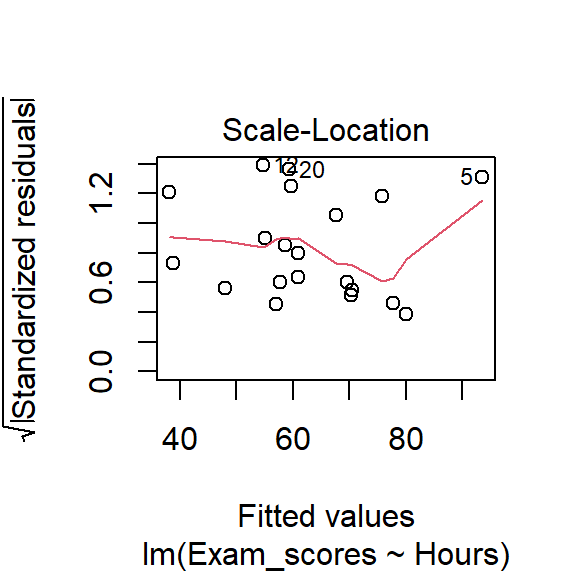

```r
#to check for homoscedasticity using the scale-location plot
plot(model, 3)
```

### To view the result of the regression model

```r
summary(model)
```

```
##
## Call:
## lm(formula = Exam_scores ~ Hours)
##
## Residuals:
##      Min       1Q   Median       3Q      Max
## -16.9547  -6.0337   0.2892   3.8602  17.5218
##
## Coefficients:
##             Estimate Std. Error t value Pr(>|t|)
## (Intercept)  12.7623     8.2761   1.542     0.14
## Hours         2.3913     0.3831   6.242  6.9e-06 ***
## ---
## Signif. codes:  0 '***' 0.001 '**' 0.01 '*' 0.05 '.' 0.1 ' ' 1
##
## Residual standard error: 9.411 on 18 degrees of freedom
## Multiple R-squared:  0.684,  Adjusted R-squared:  0.6664
## F-statistic: 38.96 on 1 and 18 DF,  p-value: 6.896e-06
```

### Interpretation

1. Since the p-value for hours (6.9e-06) is significantly less that 0.05, we can say that there is a statistically significant association between hours and score.
2. Since the p-value for the model (6.896e-06) is less than 0.05, our model is statistically significant and hours is deemed to be useful for explaining the variation in score.
3. The adjusted r-squared of 0.6664 explains that 66.4% of the exam scores can be explained using the hours variable

### Another way to test for linearity of the variables and homoscedsticity

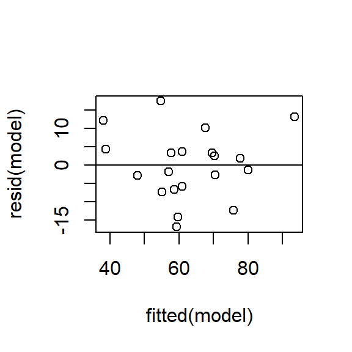

```r
#Linearity
plot(fitted(model), resid(model))
abline(0,0)
```

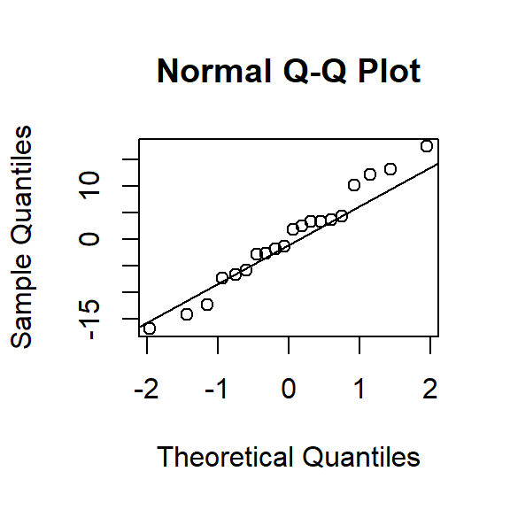

```r
#homoscedasticity
qqnorm(resid(model))
qqline(resid(model))
```

### To generate the anova table

```r
anova(model)
```

```
## Analysis of Variance Table
##
## Response: Exam_scores
##           Df Sum Sq Mean Sq F value    Pr(>F)
## Hours      1 3450.7  3450.7  38.959 6.896e-06 ***
## Residuals 18 1594.3    88.6
## ---
## Signif. codes:  0 '***' 0.001 '**' 0.01 '*' 0.05 '.' 0.1 ' ' 1
```

## Video 27: Multiple Regression Model

Multiple regression model was created using the Examerevision.sav dataset to attempt to predict examscores from hours spent revising, anxiety and A-level entry point. With the following parameters:

**Null Hypothesis: hours spent revising, anxiety and A-level entry point have no effect on exam score**

**Alternative Hypothesis: hours spent revising, anxiety and A-level entry point have an effect on exam score**

**Significance level: 0.05**

### To recreate this test in R

```r
#loading the dataset
exam_revision <-  read_sav("datasets//Example_data//examrevision.sav")
#view dataset
exam_revision
```

```
## # A tibble: 20 × 4
##    SCORE HOURS ANXIETY A_POINTS
##    <dbl> <dbl>   <dbl>    <dbl>
##  1    62    40      40       24
##  2    58    31      65       20
##  3    52    35      34       22
##  4    55    26      91       22
##  5    75    51      46       28
##  6    82    48      52       28
##  7    38    25      48       18
##  8    55    37      61       20
##  9    48    30      34       18
## 10    68    44      74       26
## 11    62    32      54       24
## 12    62    40      61       24
## 13    72    61      26       26
## 14    58    35      13       24
## 15    65    45      54       20
## 16    42    30      58       20
## 17    68    39      62       24
## 18    68    47      39       26
## 19    58    41      57       22
## 20    72    46      17       28
```

```r
#data summary
summary(exam_revision)
```

```
##      SCORE        HOURS          ANXIETY         A_POINTS
##  Min.   :38   Min.   :25.00   Min.   :13.00   Min.   :18.0
##  1st Qu.:55   1st Qu.:31.75   1st Qu.:37.75   1st Qu.:20.0
##  Median :62   Median :39.50   Median :53.00   Median :24.0
##  Mean   :61   Mean   :39.15   Mean   :49.30   Mean   :23.2
##  3rd Qu.:68   3rd Qu.:45.25   3rd Qu.:61.00   3rd Qu.:26.0
##  Max.   :82   Max.   :61.00   Max.   :91.00   Max.   :28.0
```

### To build the regression model

```r
model2 <- lm(SCORE ~ HOURS + ANXIETY + A_POINTS, exam_revision)
```

### To check if the data satisfies all the assumptions needed to carry out the test

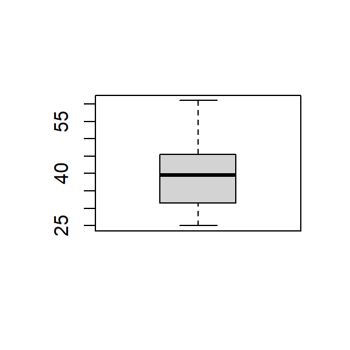

```r
#checking for outliers
attach(exam_revision)
boxplot(HOURS)
```

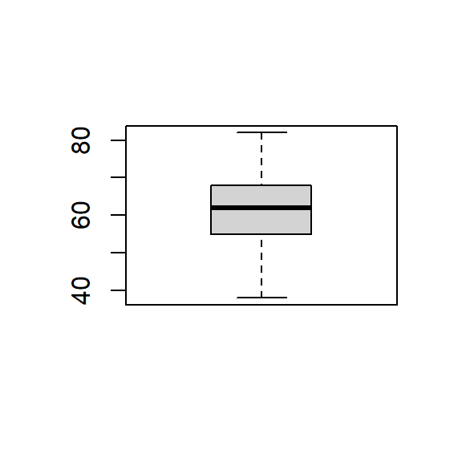

```r
boxplot(SCORE)
```

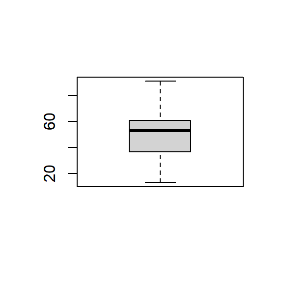

```r
boxplot(ANXIETY)
```

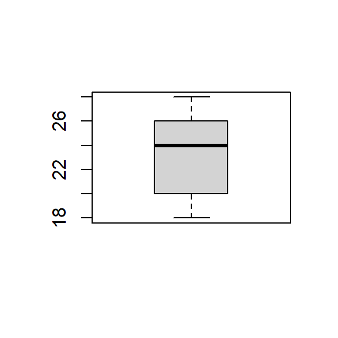

```r
boxplot(A_POINTS)
```

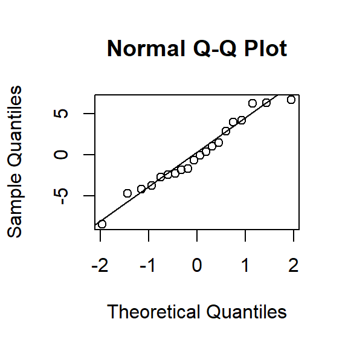

```r
#test for linearity
qqnorm(resid(model2))
qqline(resid(model2))
```

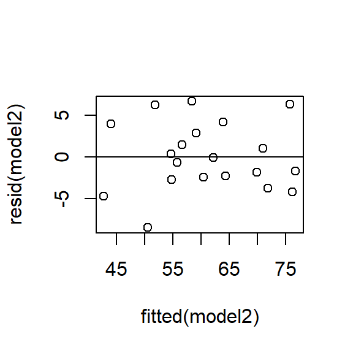

```r
#checking for homoscedasticity of the data
plot(fitted(model2), resid(model2))
abline(0,0)
```

```r
#test for multicollinearity
vif(model2)
```

```
##    HOURS  ANXIETY A_POINTS
## 2.288305 1.130329 2.152911
```

### To view the result of the regression model

```r
summary(model2)
```

```
##
## Call:
## lm(formula = SCORE ~ HOURS + ANXIETY + A_POINTS, data = exam_revision)
##
## Residuals:
##     Min      1Q  Median      3Q     Max
## -8.4933 -2.5081 -0.3897  3.1395  6.6537
##
## Coefficients:
##              Estimate Std. Error t value Pr(>|t|)
## (Intercept) -11.82254    8.80575  -1.343 0.198143
## HOURS         0.55114    0.17086   3.226 0.005284 **
## ANXIETY       0.10352    0.05762   1.796 0.091327 .
## A_POINTS      1.98888    0.46918   4.239 0.000625 ***
## ---
## Signif. codes:  0 '***' 0.001 '**' 0.01 '*' 0.05 '.' 0.1 ' ' 1
##
## Residual standard error: 4.468 on 16 degrees of freedom
## Multiple R-squared:  0.8602, Adjusted R-squared:  0.834
## F-statistic: 32.81 on 3 and 16 DF,  p-value: 4.563e-07
```

### Interpretation

- The p-values of HOURS and A_POINTS (0.0053, 0.0006) indicates that they are statistically significant in the model and can be used statistically to predict exam scores in contrary to ANXIETY
- Adjusted R-squared value of 0.834 indicates that 83.4% of the exam scores can be accounted for by the model
- The p-value of the model (4.563e-07) indicates that the model is statitically reliable

## Video 30: One-way analysis of variance test

A one-way ANOVA test was carried out to test whether the weight of parsely is inflenced byfetilizer and uses data collected by a farmer which contains weight of plants planted with biological fertilizers, chemical fertilizers and no fertilizers at all. With the following parameters:

**Null Hypothesis: fertilizer does not affect parsley weight**

**Apparent Hypothesis: fertilizer does affect parsley weight**

**Significance level: 5%**

### To recreate the test in R

```r
#loading the dataset
parsley <-  read_sav("datasets//Example_data//parsley.sav")
parsley$fertilizer <- as_label(parsley$fertilizer)
#descriptive analysis of dataset
summary(parsley)
```

```
##       fertilizer     weight
##  None      :30   Min.   :36.00
##  Biological:30   1st Qu.:48.00
##  Chemical  :30   Median :54.00
##                  Mean   :53.93
##                  3rd Qu.:61.00
##                  Max.   :73.00
```

```r
#descriptive analysis for dataset for each categorical groups
parsley %>% group_by(fertilizer) %>% summarise(count= n(),mean = mean(weight),
                                             sd = sd(weight), min = min(weight),
                                             max = max(weight))
```

```
## # A tibble: 3 × 6
##   fertilizer count  mean    sd   min   max
##   <fct>      <int> <dbl> <dbl> <dbl> <dbl>
## 1 None          30  51.2  7.84    38    68
## 2 Biological    30  53.6  8.86    36    71
## 3 Chemical      30  57.0  7.85    42    73
```

### To check if the data satisfies all the assumptions needed to carry out the test

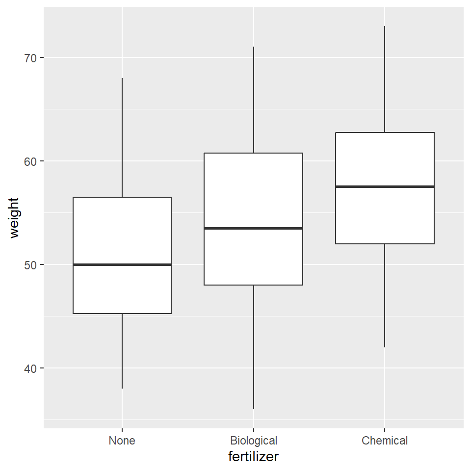

```r
#checking for outliers
ggplot(parsley, aes(fertilizer, weight)) + geom_boxplot()
```

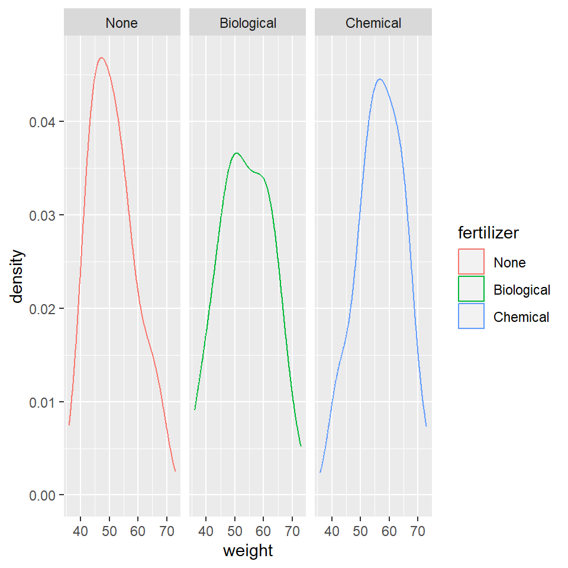

```r
#checking for normal disribution for each categorical group
ggplot(parsley, aes(weight, color = fertilizer)) + geom_density() + facet_wrap(~fertilizer)
```

```r
#checking for homogeneity of variance using Levene's test
leveneTest(weight ~ fertilizer, parsley)
```

```
## Levene's Test for Homogeneity of Variance (center = median)
##       Df F value Pr(>F)
## group  2  0.5377  0.586
##       87
```

- The boxplot shows the absences of outliers
- The density plots indicates an approximate normal distribution for each categorical groups and
- The Levene’s test fail to reject the null hypothesis (p-value > 0.05) and hence confirms homogeneity of variances.

The data set satisfies all assumptions to carry out test.

### Carrying out the test

```r
parsley.aov <- aov(weight ~ fertilizer, parsley)
summary(parsley.aov)
```

```
##             Df Sum Sq Mean Sq F value Pr(>F)
## fertilizer   2    503  251.43   3.743 0.0276 *
## Residuals   87   5845   67.18
## ---
## Signif. codes:  0 '***' 0.001 '**' 0.01 '*' 0.05 '.' 0.1 ' ' 1
```

#### Performing a post hoc test

```r
#recreating the tuckey test
parsley.tukey <- TukeyHSD(parsley.aov)
parsley.tukey
```

```
##   Tukey multiple comparisons of means
##     95% family-wise confidence level
##
## Fit: aov(formula = weight ~ fertilizer, data = parsley)
##
## $fertilizer
##                         diff        lwr       upr     p adj
## Biological-None     2.433333 -2.6129392  7.479606 0.4863309
## Chemical-None       5.766667  0.7203941 10.812939 0.0210196
## Chemical-Biological 3.333333 -1.7129392  8.379606 0.2618374
```

### Interpretation

There was a statistically significant difference in the weight of plants between groups as determined by the one-way ANOVA test (f(2,87) = 3.743, p = 0.0276) and a tuckey post hoc test revealed that the weight of the parsley plants was statistically significantly lower for plants with no fertilizer than those with chemical fertilizer (p = 0.021). They were no statistically significant differences between plants with biological fertilizers and those with chemical fertilizers (p = 0.262) and the plants with biological fertilizers and no fertilizers at all (p = 0.486)